# TASK 3 CODSOFT

## TASK - 3

## SALES PREDICTION USING PYTHON

## JAN BATCH A30

## Introduction to the Sales Prediction Dataset:

This dataset captures the advertising expenses in three different media channels - TV, Radio, and Newspaper - and the corresponding sales figures. Each row in the dataset represents a set of observations for a specific instance, where the advertising expenditures on each channel are associated with the sales outcome.

## Columns in the dataset:

TV: The amount spent on advertising on TV.

Radio: The amount spent on advertising on the radio.

Newspaper: The amount spent on advertising in newspapers.

Sales: The actual sales figures corresponding to the advertising expenditures.

The objective of utilizing machine learning techniques on this dataset is to build a predictive model that can estimate sales based on the advertising expenses across different channels. By analyzing and interpreting this data, businesses can make informed decisions on optimizing their advertising strategies, ultimately maximizing sales potential.

```python
import numpy as np
import pandas as pd
import matplotlib.pyplot as plt
import seaborn as sns
from sklearn.model_selection import train_test_split
import statsmodels.api as sm
from sklearn.metrics import mean_squared_error
from sklearn.metrics import r2_score
```

```python
df = pd.DataFrame(pd.read_csv("C:/Users/MANOJ S/Downloads/advertising.csv"))
df.head()
```

|  | TV | Radio | Newspaper | Sales |
| --- | --- | --- | --- | --- |
| 0 | 230.1 | 37.8 | 69.2 | 22.1 |
| 1 | 44.5 | 39.3 | 45.1 | 10.4 |
| 2 | 17.2 | 45.9 | 69.3 | 12.0 |
| 3 | 151.5 | 41.3 | 58.5 | 16.5 |
| 4 | 180.8 | 10.8 | 58.4 | 17.9 |

```python
df.shape
```

```
(200, 4)
```

```python
df.info()
```

```
<class 'pandas.core.frame.DataFrame'>
RangeIndex: 200 entries, 0 to 199
Data columns (total 4 columns):
 #   Column     Non-Null Count  Dtype
---  ------     --------------  -----
 0   TV         200 non-null    float64
 1   Radio      200 non-null    float64
 2   Newspaper  200 non-null    float64
 3   Sales      200 non-null    float64
dtypes: float64(4)
memory usage: 6.4 KB
```

```python
df.describe()
```

|  | TV | Radio | Newspaper | Sales |
| --- | --- | --- | --- | --- |
| count | 200.000000 | 200.000000 | 200.000000 | 200.000000 |
| mean | 147.042500 | 23.264000 | 30.554000 | 15.130500 |
| std | 85.854236 | 14.846809 | 21.778621 | 5.283892 |
| min | 0.700000 | 0.000000 | 0.300000 | 1.600000 |
| 25% | 74.375000 | 9.975000 | 12.750000 | 11.000000 |
| 50% | 149.750000 | 22.900000 | 25.750000 | 16.000000 |
| 75% | 218.825000 | 36.525000 | 45.100000 | 19.050000 |
| max | 296.400000 | 49.600000 | 114.000000 | 27.000000 |

```python
df.isnull().sum()*100/df.shape[0]
```

```
TV           0.0
Radio        0.0
Newspaper    0.0
Sales        0.0
dtype: float64
```

[output not shown]

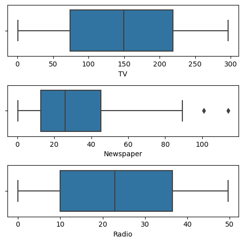

```python
# Outlier Analysis
fig, axs = plt.subplots(3, figsize=(5, 5))
plt1 = sns.boxplot(df['TV'], ax=axs[0])
plt2 = sns.boxplot(df['Newspaper'], ax=axs[1])
plt3 = sns.boxplot(df['Radio'], ax=axs[2])
plt.tight_layout()

plt.show()
```

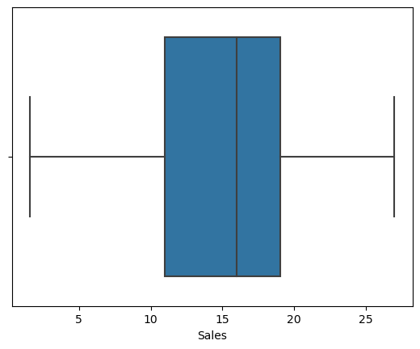

```python
# Boxplot for Sales
sns.boxplot(x=df['Sales'])
plt.show()
```

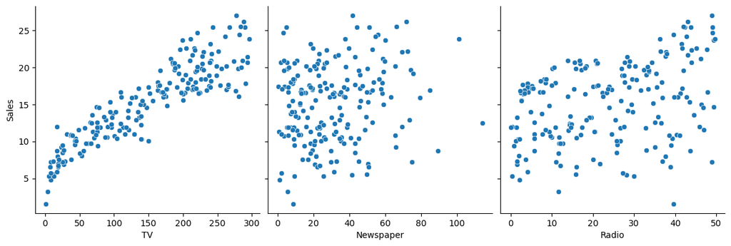

```python
# Scatter plots for Sales vs. other variables
sns.pairplot(df, x_vars=['TV', 'Newspaper', 'Radio'], y_vars='Sales', height=4, aspect=1, kind='scatter')
plt.show()
```

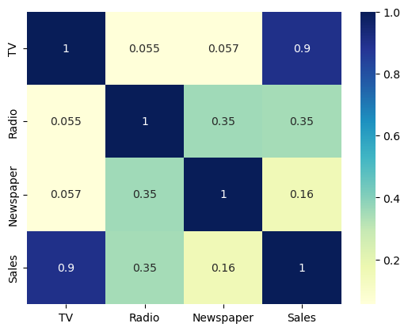

```python
# Correlation matrix heatmap for all variables
sns.heatmap(df.corr(), cmap="YlGnBu", annot=True)
plt.show()
```

## Model Building

```python
X = df['TV']
y = df['Sales']
```

```python
X
```

```
0      230.1
1       44.5
2       17.2
3      151.5
4      180.8
       ...
195     38.2
196     94.2
197    177.0
198    283.6
199    232.1
Name: TV, Length: 200, dtype: float64
```

```python
y
```

```
0      22.1
1      10.4
2      12.0
3      16.5
4      17.9
       ...
195     7.6
196    14.0
197    14.8
198    25.5
199    18.4
Name: Sales, Length: 200, dtype: float64
```

```python
X_train, X_test, y_train, y_test = train_test_split(X, y, train_size = 0.7, test_size = 0.3, random_state = 100)
```

```python
X_train.head()
```

```
74     213.4
3      151.5
185    205.0
26     142.9
90     134.3
Name: TV, dtype: float64
```

```python
y_train.head()
```

```
74     17.0
3      16.5
185    22.6
26     15.0
90     14.0
Name: Sales, dtype: float64
```

```python
# Add a constant to get an intercept
X_train_sm = sm.add_constant(X_train)

# Fit the resgression line using 'OLS'
lr = sm.OLS(y_train, X_train_sm).fit()

# Print the summary of the regression
print(lr.summary())
```

```
                            OLS Regression Results
==============================================================================
Dep. Variable:                  Sales   R-squared:                       0.816
Model:                            OLS   Adj. R-squared:                  0.814
Method:                 Least Squares   F-statistic:                     611.2
Date:                Sat, 24 Feb 2024   Prob (F-statistic):           1.52e-52
Time:                        20:40:20   Log-Likelihood:                -321.12
No. Observations:                 140   AIC:                             646.2
Df Residuals:                     138   BIC:                             652.1
Df Model:                           1
Covariance Type:            nonrobust
==============================================================================
                 coef    std err          t      P>|t|      [0.025      0.975]
------------------------------------------------------------------------------
const          6.9487      0.385     18.068      0.000       6.188       7.709
TV             0.0545      0.002     24.722      0.000       0.050       0.059
==============================================================================
Omnibus:                        0.027   Durbin-Watson:                   2.196
Prob(Omnibus):                  0.987   Jarque-Bera (JB):                0.150
Skew:                          -0.006   Prob(JB):                        0.928
Kurtosis:                       2.840   Cond. No.                         328.
==============================================================================

Notes:
[1] Standard Errors assume that the covariance matrix of the errors is correctly specified.
```

```python
lr.params
```

```
const    6.948683
TV       0.054546
dtype: float64
```

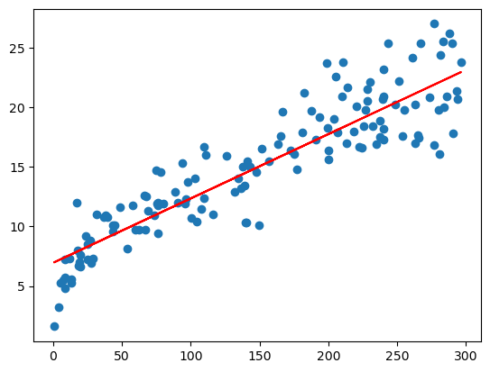

```python
plt.scatter(X_train, y_train)
plt.plot(X_train, 6.948 + 0.054*X_train, 'r')
plt.show()
```

```python
y_train_pred = lr.predict(X_train_sm)
res = (y_train - y_train_pred)
```

[output not shown]

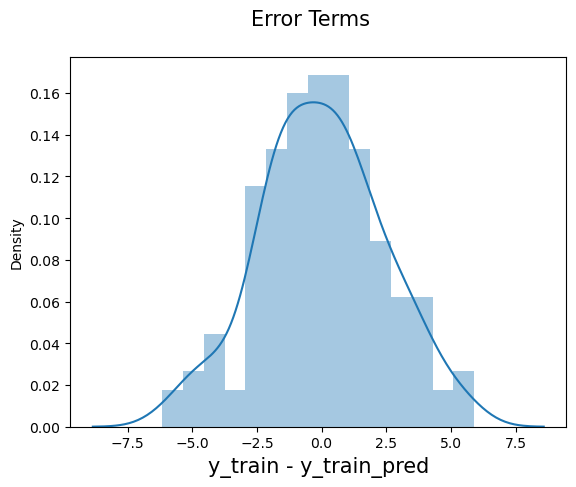

```python
fig = plt.figure()
sns.distplot(res, bins = 15)
fig.suptitle('Error Terms', fontsize = 15)
plt.xlabel('y_train - y_train_pred', fontsize = 15)
plt.show()
```

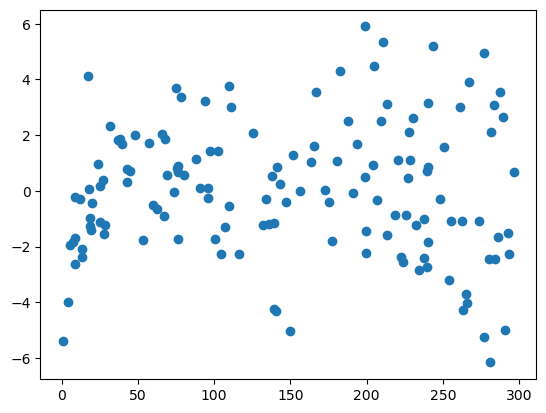

```python
plt.scatter(X_train,res)
plt.show()
```

```python
# Add a constant to X_test
X_test_sm = sm.add_constant(X_test)

# Predict the y values corresponding to X_test_sm
y_pred = lr.predict(X_test_sm)
```

```python
X_test_sm
```

|  | const | TV |
| --- | --- | --- |
| 126 | 1.0 | 7.8 |
| 104 | 1.0 | 238.2 |
| 99 | 1.0 | 135.2 |
| 92 | 1.0 | 217.7 |
| 111 | 1.0 | 241.7 |
| 167 | 1.0 | 206.8 |
| 116 | 1.0 | 139.2 |
| 96 | 1.0 | 197.6 |
| 52 | 1.0 | 216.4 |
| 69 | 1.0 | 216.8 |
| 164 | 1.0 | 117.2 |
| 124 | 1.0 | 229.5 |
| 182 | 1.0 | 56.2 |
| 154 | 1.0 | 187.8 |
| 125 | 1.0 | 87.2 |
| 196 | 1.0 | 94.2 |
| 194 | 1.0 | 149.7 |
| 177 | 1.0 | 170.2 |
| 163 | 1.0 | 163.5 |
| 31 | 1.0 | 112.9 |
| 11 | 1.0 | 214.7 |
| 73 | 1.0 | 129.4 |
| 15 | 1.0 | 195.4 |
| 41 | 1.0 | 177.0 |
| 97 | 1.0 | 184.9 |
| 128 | 1.0 | 220.3 |
| 133 | 1.0 | 219.8 |
| 82 | 1.0 | 75.3 |
| 139 | 1.0 | 184.9 |
| 123 | 1.0 | 123.1 |
| 83 | 1.0 | 68.4 |
| 65 | 1.0 | 69.0 |
| 151 | 1.0 | 121.0 |
| 162 | 1.0 | 188.4 |
| 170 | 1.0 | 50.0 |
| 77 | 1.0 | 120.5 |
| 32 | 1.0 | 97.2 |
| 173 | 1.0 | 168.4 |
| 174 | 1.0 | 222.4 |
| 85 | 1.0 | 193.2 |
| 168 | 1.0 | 215.4 |
| 112 | 1.0 | 175.7 |
| 171 | 1.0 | 164.5 |
| 181 | 1.0 | 218.5 |
| 7 | 1.0 | 120.2 |
| 46 | 1.0 | 89.7 |
| 75 | 1.0 | 16.9 |
| 28 | 1.0 | 248.8 |
| 29 | 1.0 | 70.6 |
| 195 | 1.0 | 38.2 |
| 40 | 1.0 | 202.5 |
| 153 | 1.0 | 171.3 |
| 115 | 1.0 | 75.1 |
| 64 | 1.0 | 131.1 |
| 59 | 1.0 | 210.7 |
| 1 | 1.0 | 44.5 |
| 192 | 1.0 | 17.2 |
| 136 | 1.0 | 25.6 |
| 152 | 1.0 | 197.6 |
| 161 | 1.0 | 85.7 |

```python
y_pred
```

```
126     7.374140
104    19.941482
99     14.323269
92     18.823294
111    20.132392
167    18.228745
116    14.541452
96     17.726924
52     18.752384
69     18.774202
164    13.341445
124    19.466933
182    10.014155
154    17.192376
125    11.705073
```

[output cut: 46 more lines]

```python
y_pred.head()
```

```
126     7.374140
104    19.941482
99     14.323269
92     18.823294
111    20.132392
dtype: float64
```

```python
np.sqrt(mean_squared_error(y_test, y_pred))
```

```
2.019296008966232
```

```python
r_squared = r2_score(y_test, y_pred)
r_squared
```

```
0.792103160124566
```

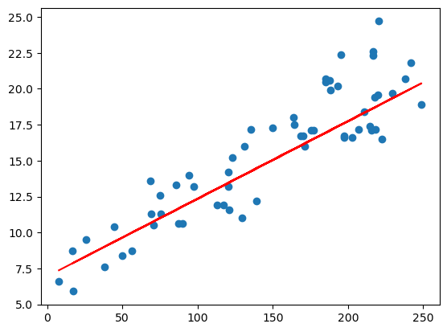

```python
plt.scatter(X_test, y_test)
plt.plot(X_test, 6.948 + 0.054 * X_test, 'r')
plt.show()
```

Dep. Variable: This is the dependent variable in your regression analysis, which is 'Sales' in this case.

Model: It indicates that the model used is OLS (Ordinary Least Squares), which is a common method for linear regression.

R-squared: R-squared measures the proportion of the variance in the dependent variable that is predictable from the independent variable(s). In this case, R-squared is 0.816, indicating that approximately 81.6% of the variability in 'Sales' is explained by the linear regression model.

Adj. R-squared: Adjusted R-squared is a modified version of R-squared that adjusts for the number of predictors in the model. It is slightly lower than R-squared and provides a more realistic estimate of the model's explanatory power.

F-statistic: The F-statistic is a measure of how well the overall regression model fits the data. A higher F-statistic suggests a better fit. In this case, the F-statistic is 611.2.

Prob (F-statistic): This is the p-value associated with the F-statistic. A low p-value (less than 0.05) indicates that the overall model is statistically significant. In this case, the p-value is very close to zero (1.52e-52), indicating that the model is significant.

coef: These are the coefficients of the model. 'const' represents the intercept, and 'TV' represents the coefficient for the 'TV' variable.

std err: Standard error measures the variability of the coefficient estimate.

t: The t-statistic is a measure of how many standard errors the coefficient is away from zero. A higher absolute t-value suggests that the coefficient is significant.

P>|t|: This is the p-value associated with the t-statistic. A low p-value (less than 0.05) indicates that the individual predictor is statistically significant.

[0.025 0.975]: These are the lower and upper bounds of the 95% confidence interval for the coefficients.

The Ordinary Least Squares (OLS) regression results show that the linear model predicts 'Sales' based on the 'TV' variable with a coefficient of 0.0545 and an intercept of 6.9487. The model has an R-squared value of 0.816, indicating that approximately 81.6% of the variability in 'Sales' is explained by the linear relationship with 'TV'. Both the intercept and the 'TV' coefficient are statistically significant with p-values close to zero. The F-statistic of 611.2 and its associated p-value (1.52e-52) suggest that the overall model is highly significant. These findings suggest that the linear regression model, incorporating the 'TV' variable, provides a statistically significant and explanatory framework for predicting 'Sales' in the dataset.